# Some R solutions for Assign 1

Michael Friendly

2026-01-18

Here, I just provide some of the steps I would do to to find answers to these questions with R. ## Exercise 2.2 ### (a) Abortion opinion data

```r
data(Abortion, package="vcdExtra")
str(Abortion)
```

```
##  'table' num [1:2, 1:2, 1:2] 171 152 138 167 79 148 112 133
##  - attr(*, "dimnames")=List of 3
##   ..$ Sex             : chr [1:2] "Female" "Male"
##   ..$ Status          : chr [1:2] "Lo" "Hi"
##   ..$ Support_Abortion: chr [1:2] "Yes" "No"
```

`Support_Abortion` is the response, `Sex` and `Status` are binary, nominal explanatory variables. Q: How does support for abortion depend on sex and status? ## (b) Caesarian Births: Caesar

```r
data(Caesar, package = "vcdExtra")
str(Caesar)
```

```
##  'table' num [1:3, 1:2, 1:2, 1:2] 0 1 17 0 1 1 11 17 30 4 ...
##  - attr(*, "dimnames")=List of 4
##   ..$ Infection  : chr [1:3] "Type 1" "Type 2" "None"
##   ..$ Risk       : chr [1:2] "Yes" "No"
##   ..$ Antibiotics: chr [1:2] "Yes" "No"
##   ..$ Planned    : chr [1:2] "Yes" "No"
```

`Infection` is a 3-level response variable; the explanatory variables are: * `Risk` (a two-level nominal variable), * whether `Antibiotics` were used (a two-level nominal variable), and * whether the Caesarian section was `Planned` or not (a two-level nominal variable).

Q: How antibiotics, risk, and whether the operation was planned are associated with infection type (or no infection)? Similarly for the other two datasets ## Exercise 2.4: Danish Welfare

```r
library(vcdExtra)
data(DanishWelfare, package="vcdExtra")
str(DanishWelfare)
```

```
## 'data.frame':    180 obs. of  5 variables:
##  $ Freq   : num  1 4 1 8 6 14 8 41 100 175 ...
##  $ Alcohol: Factor w/ 3 levels "<1","1-2",">2": 1 1 1 1 1 1 1 1 1 1 ...
##  $ Income : Factor w/ 4 levels "0-50","50-100",..: 1 1 1 1 1 1 1 1 1 1 ...
##  $ Status : Factor w/ 3 levels "Widow","Married",..: 1 1 1 1 1 2 2 2 2 2 ...
##  $ Urban  : Factor w/ 5 levels "Copenhagen","SubCopenhagen",..: 1 2 3 4 5 1 2 3 4 5 ...
```

```r
sum(DanishWelfare$Freq)  # total cases
```

```
## [1] 5144
```

### Ordering Alcohol and Income

First, examine the levels of the factor. Then, use `ordered()` to assign labels to the ordered levels of `Alcohol`

```r
levels(DanishWelfare$Alcohol)
```

```
## [1] "<1"  "1-2" ">2"
```

```r
DanishWelfare$Alcohol <- ordered(DanishWelfare$Alcohol, levels=c("<1", "1-2", ">2"))
```

Do the same for `Income`

```r
levels(DanishWelfare$Income)
```

```
## [1] "0-50"    "50-100"  "100-150" ">150"
```

```r
DanishWelfare$Income <- ordered(DanishWelfare$Income, levels=c("0-50","50-100","100-150",">150"))
```

or, simpler, using as.ordered():

```r
DanishWelfare$Alcohol <- as.ordered(DanishWelfare$Alcohol)
DanishWelfare$Income <- as.ordered(DanishWelfare$Income)
```

now they are **ordered factors**

```r
str(DanishWelfare)
```

```
## 'data.frame':    180 obs. of  5 variables:
##  $ Freq   : num  1 4 1 8 6 14 8 41 100 175 ...
##  $ Alcohol: Ord.factor w/ 3 levels "<1"<"1-2"<">2": 1 1 1 1 1 1 1 1 1 1 ...
##  $ Income : Ord.factor w/ 4 levels "0-50"<"50-100"<..: 1 1 1 1 1 1 1 1 1 1 ...
##  $ Status : Factor w/ 3 levels "Widow","Married",..: 1 1 1 1 1 2 2 2 2 2 ...
##  $ Urban  : Factor w/ 5 levels "Copenhagen","SubCopenhagen",..: 1 2 3 4 5 1 2 3 4 5 ...
```

### convert to table form

```r
Danish.tab <- xtabs(DanishWelfare)
# same, using formula method
Danish.tab <- xtabs(Freq ~ ., data=DanishWelfare)

str(Danish.tab)
```

```
##  'xtabs' num [1:3, 1:4, 1:3, 1:5] 1 3 2 8 1 3 2 5 2 42 ...
##  - attr(*, "dimnames")=List of 4
##   ..$ Alcohol: chr [1:3] "<1" "1-2" ">2"
##   ..$ Income : chr [1:4] "0-50" "50-100" "100-150" ">150"
##   ..$ Status : chr [1:3] "Widow" "Married" "Unmarried"
##   ..$ Urban  : chr [1:5] "Copenhagen" "SubCopenhagen" "LargeCity" "City" ...
##  - attr(*, "call")= language xtabs(formula = Freq ~ ., data = DanishWelfare)
```

```r
structable(Danish.tab)
```

```
##                   Income       0-50                                          50-100                                         100-150                                            >150
##                   Urban  Copenhagen SubCopenhagen LargeCity City Country Copenhagen SubCopenhagen LargeCity City Country Copenhagen SubCopenhagen LargeCity City Country Copenhagen SubCopenhagen LargeCity City Country
## Alcohol Status
## <1      Widow                     1             4         1    8       6          8             2         7   14       5          2             3         1    5       2         42            29        17   95      46
##         Married                  14             8        41  100     175         42            51        62  234     255         21            30        23   87      77         24            30        50  167     232
##         Unmarried                 6             1         2    6       9          7             5         9   20      27          3             2         1   12       4         33            24        15   64      68
## 1-2     Widow                     3             0         1    4       2          1             1         3    8       4          5             4         1    9       4         26            34        14   48      24
##         Married                  15             7        15   25      48         39            59        68  172     143         32            68        43  128      86         43            76        70  198     136
##         Unmarried                 2             3         9    9       7         12             3        11   20      23          6            10         5   21      15         36            23        48   89      64
## >2      Widow                     2             0         2    1       0          3             0         2    1       3          2             1         1    1       0         21            13         5   20       8
##         Married                   1             2         2    7       7         14            21        14   38      35         20            31        10   36      21         23            47        21   53      36
##         Unmarried                 3             0         1    5       1          2             0         3   12      13          0             2         3    9       7         38            20        13   39      26
```

### Urban factor

```r
margin.table(Danish.tab, 4)
```

```
## Urban
##    Copenhagen SubCopenhagen     LargeCity          City       Country
##           552           614           594          1765          1619
```

Collapse categories

```r
Danish.tab2 <- collapse.table(Danish.tab, Urban=c("City","City","City","City","NonCity"))

structable(Danish.tab2)
```

```
##                   Income 0-50         50-100         100-150         >150
##                   Urban  City NonCity   City NonCity    City NonCity City NonCity
## Alcohol Status
## <1      Widow              14       6     31       5      11       2  183      46
##         Married           163     175    389     255     161      77  271     232
##         Unmarried          15       9     41      27      18       4  136      68
## 1-2     Widow               8       2     13       4      19       4  122      24
##         Married            62      48    338     143     271      86  387     136
##         Unmarried          23       7     46      23      42      15  196      64
## >2      Widow               5       0      6       3       5       0   59       8
##         Married            12       7     87      35      97      21  144      36
##         Unmarried           9       1     17      13      14       7  110      26
```

```r
structable(Alcohol ~ Urban+Status+Income,  Danish.tab2)
```

```
##                           Alcohol  <1 1-2  >2
## Urban   Status    Income
## City    Widow     0-50             14   8   5
##                   50-100           31  13   6
##                   100-150          11  19   5
##                   >150            183 122  59
##         Married   0-50            163  62  12
##                   50-100          389 338  87
##                   100-150         161 271  97
##                   >150            271 387 144
##         Unmarried 0-50             15  23   9
##                   50-100           41  46  17
##                   100-150          18  42  14
##                   >150            136 196 110
## NonCity Widow     0-50              6   2   0
##                   50-100            5   4   3
##                   100-150           2   4   0
##                   >150             46  24   8
##         Married   0-50            175  48   7
##                   50-100          255 143  35
##                   100-150          77  86  21
##                   >150            232 136  36
##         Unmarried 0-50              9   7   1
##                   50-100           27  23  13
##                   100-150           4  15   7
##                   >150             68  64  26
```

## Exercise 2.5 The dataset `UKSoccer` is a square table of goals scored by Home/Away teams

```r
data(UKSoccer, package="vcd")
# (a) total games
sum(UKSoccer)
```

```
## [1] 380
```

```r
# (b) marginal totals
addmargins(UKSoccer)
```

```
##      Away
## Home    0   1   2   3   4 Sum
##   0    27  29  10   8   2  76
##   1    59  53  14  12   4 142
##   2    28  32  14  12   4  90
##   3    19  14   7   4   1  45
##   4     7   8  10   2   0  27
##   Sum 140 136  55  38  11 380
```

```r
# or
rowSums(UKSoccer)
```

```
##   0   1   2   3   4
##  76 142  90  45  27
```

```r
colSums(UKSoccer)
```

```
##   0   1   2   3   4
## 140 136  55  38  11
```

```r
# or
home <- margin.table(UKSoccer, 1)
away <- margin.table(UKSoccer, 2)

# (c) proportions
prop.table(margin.table(UKSoccer,1))
```

```
## Home
##          0          1          2          3          4
## 0.20000000 0.37368421 0.23684211 0.11842105 0.07105263
```

```r
prop.table(margin.table(UKSoccer,2))
```

```
## Away
##          0          1          2          3          4
## 0.36842105 0.35789474 0.14473684 0.10000000 0.02894737
```

```r
# compare distribution of home & away goals
library(vcd)
goodfit(home, type="poisson")
```

[output not shown]

```r
goodfit(away, type="poisson")
```

```
##
## Observed and fitted values for poisson distribution
## with parameters estimated by `ML'
##
##  count observed     fitted pearson residual
##      0      140 131.238117        0.7648345
##      1      136 139.526840       -0.2985774
##      2       55  74.169531       -2.2258645
##      3       38  26.284641        2.2850967
##      4       11   6.986181        0.7488822
```

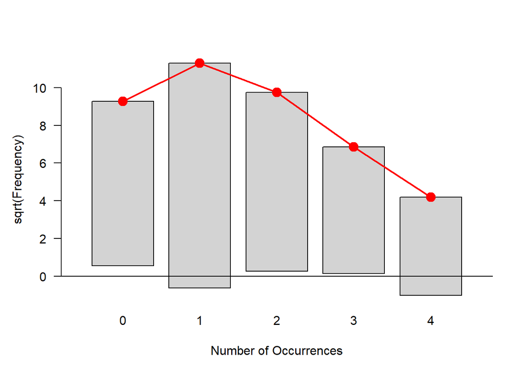

```r
plot(goodfit(home, type="poisson"))
```

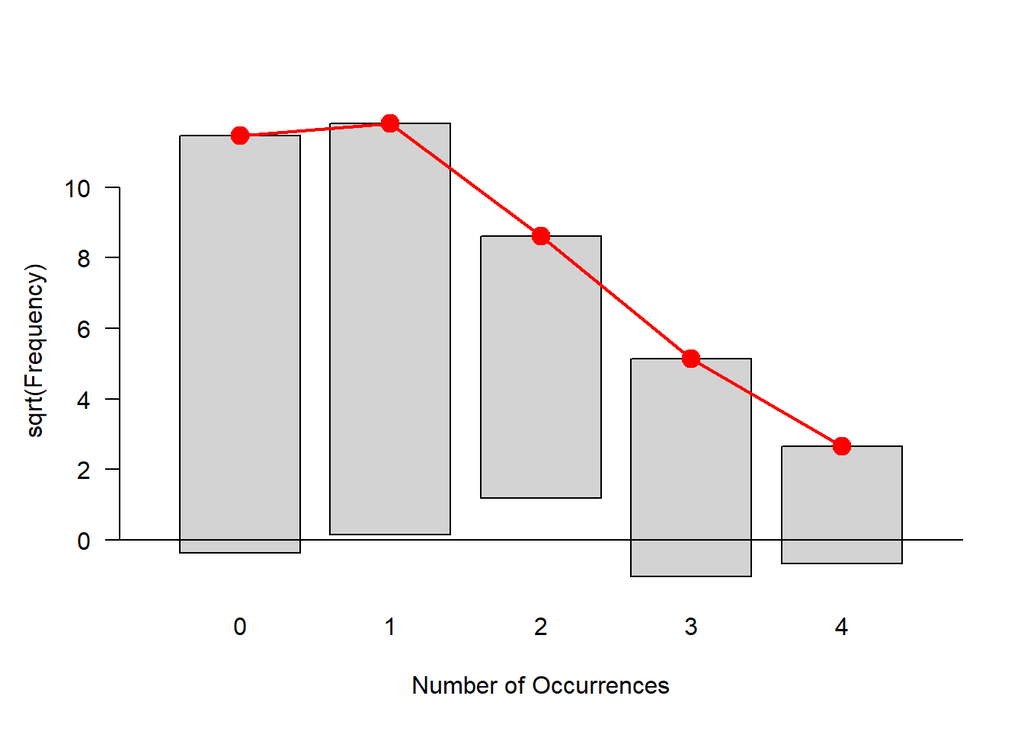

```r
plot(goodfit(away, type="poisson"))
```

```r
# make a 5 x 2 table
tab <- rbind(home,away)
names(dimnames(tab)) <- c("Team", "Goals")
chisq.test(tab)
```

```
##
##  Pearson's Chi-squared test
##
## data:  tab
## X-squared = 34.868, df = 4, p-value = 4.945e-07
```

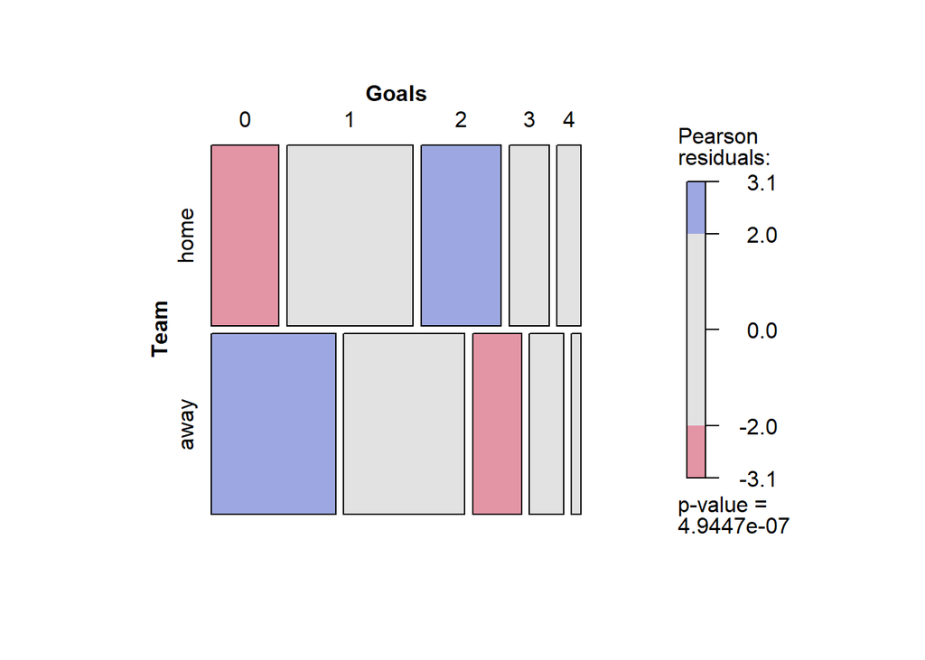

```r
mosaic(tab, shade=TRUE)
```

```r
# mean goals scores-- need to use weighted.mean ...
weighted.mean(0:4, w=home)
```

```
## [1] 1.486842
```

```r
weighted.mean(0:4, w=away)
```

```
## [1] 1.063158
```

```r
# ... or else expand frequencies to a data frame of 380 games
Home <- rep(0:4, times=home)
Away <- rep(0:4, times=away)
HA <- data.frame(Home, Away)
summary(HA)
```

```
##       Home            Away
##  Min.   :0.000   Min.   :0.000
##  1st Qu.:1.000   1st Qu.:0.000
##  Median :1.000   Median :1.000
##  Mean   :1.487   Mean   :1.063
##  3rd Qu.:2.000   3rd Qu.:2.000
##  Max.   :4.000   Max.   :4.000
```

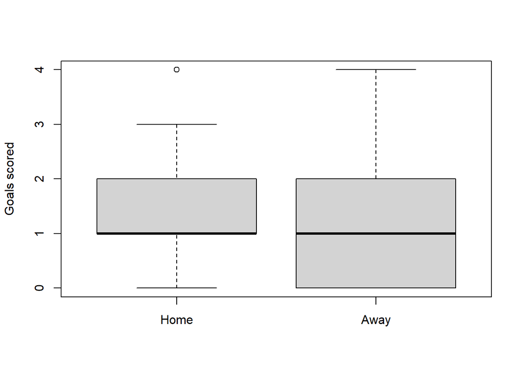

```r
boxplot(HA, ylab="Goals scored")
```